# Bayesian Inference for Simple Linear Regression (Ch.14), Part II

AG Schissler

04/17/2019

## How well does the first midterm score predict the third midterm score? (5 - 10 min)

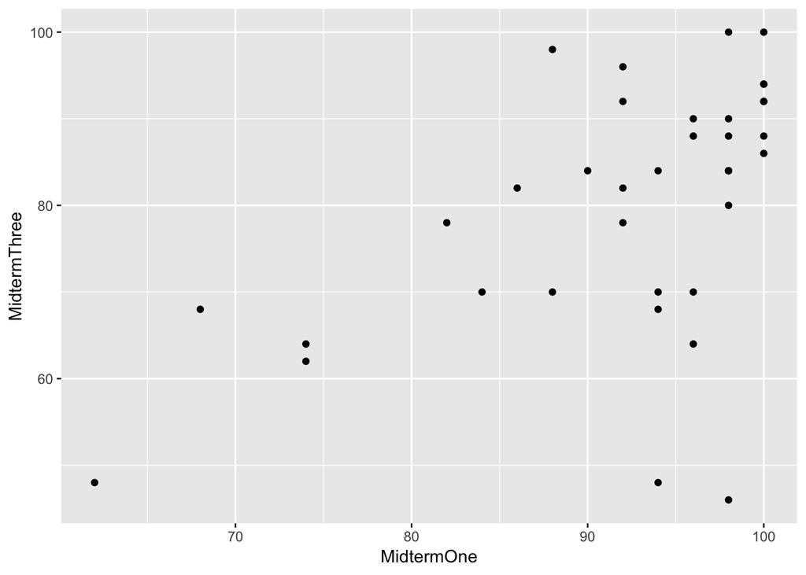

```r
### load scrambled midterm one and midterm three scores
reg_data <- readRDS("exam_reg_data.rds")

## visualize relationship
ggplot2::qplot(x = MidtermOne, y = MidtermThree, data = reg_data)
```

```r
### explore numerically
(x_bar <- mean(reg_data$MidtermOne))
```

```
## [1] 92.10811
```

```r
(y_bar <- mean(reg_data$MidtermThree))
```

```
## [1] 79.89189
```

```r
(xy_bar <- mean(reg_data$MidtermOne * reg_data$MidtermThree))
```

```
## [1] 7427.892
```

```r
(x2_bar <- mean(reg_data$MidtermOne^2))
```

```
## [1] 8569.73
```

```r
(x_bar2 <- mean(reg_data$MidtermOne)^2)
```

```
## [1] 8483.904
```

### Please compute the least squares estimates of $\alpha_0, \beta$ and $\alpha_{\overline{x}}$.

for the equations, $\mu_{y|x} = \alpha_0 + \beta x$ or, equivalently, $\mu_{y|x} = \alpha_{\overline{x}} + \beta \left( x - \overline{x} \right)$.

### Now let’s compute the variance estimator

$\hat{\sigma^2} = \frac{\sum_{i=1}^n (y_i - \hat{y_i})^2}{n-2}$.

```r
compute_simple_ls <- function(x, y) {
    B <- ( mean(x*y) - mean(x) * mean(y) ) / ( mean(x^2) - mean(x)^2  )
    A0 <- mean(y) - B * mean(x)
    return( list(A0 = A0, B = B) )
}

my_ls_soln <- compute_simple_ls(x = reg_data$MidtermOne, y = reg_data$MidtermThree)

## x <- reg_data$MidtermOne
## y <- reg_data$MidtermThree

compute_sigma_hat <- function(x, y){
    ls_estimator <- compute_simple_ls(x = x, y = y)
    y_hat <- ls_estimator$A0 + ls_estimator$B * x
    ## variance estimator
    sqrt( sum( (y - y_hat)^2 ) / ( length(x) - 2 ) )
}

compute_sigma_hat(x = reg_data$MidtermOne, y = reg_data$MidtermThree)
```

```
## [1] 12.41096
```

```r
summary(lm(MidtermThree ~ MidtermOne, data = reg_data))
```

```
##
## Call:
## lm(formula = MidtermThree ~ MidtermOne, data = reg_data)
##
## Residuals:
##     Min      1Q  Median      3Q     Max
## -38.642  -3.354   2.195   6.970  21.420
##
## Coefficients:
##             Estimate Std. Error t value Pr(>|t|)
## (Intercept)   5.6259    20.3882   0.276 0.784216
## MidtermOne    0.8063     0.2202   3.661 0.000822 ***
## ---
## Signif. codes:  0 '***' 0.001 '**' 0.01 '*' 0.05 '.' 0.1 ' ' 1
##
## Residual standard error: 12.41 on 35 degrees of freedom
## Multiple R-squared:  0.2769, Adjusted R-squared:  0.2562
## F-statistic:  13.4 on 1 and 35 DF,  p-value: 0.0008221
```

## I. Prior specification in Bayes Theorem for the regression model (14.4 part II; 20 - 25 min)

### Joint prior for $\beta$ and $\alpha_{\overline{x}}$

$g(\alpha_{\overline{x}}, \beta) = g(\alpha_{\overline{x}}) \times g(\beta)$.

This assumes independence (not required, but it is reasonable). To get simple updating rules for the posterior, choose either a flat prior (which is also Jeffrey’s prior in the normal model) or a normal prior for each parameter.

### The role of standardization in prior specification

Discuss…

### Community of priors

Let’s form a *community of priors* for this regression problem.

1. Moderate Skeptical view
2. Highly Skeptical view
3. Moderate Optimistic view
4. Highly Optimistic view
5. Reference (aka “flat”)
6. Weakly informative (aka weakly skeptical)

Use the guidelines in Bolstad for normal priors…

## II. The joint posterior for $\beta$ and $\alpha_{\overline{x}}$ (14.5; 15 - 20 min)

### Walk through p.295.

### Updating rules under a normal prior

See text equations 14.7, 14.8 and two equations below.

### Example 14.2

Discuss.

### Please find the posterior under your prior from earlier

Assume unknown variance.

Then we’ll combine into and explore…

```
## Standard deviation of residuals:  12.4
```

```
##             Posterior Mean Posterior Std. Deviation
##             -------------- ------------------------
## Intercept:  79.89          2.0403
## Slope:      0.8063         0.22024
```

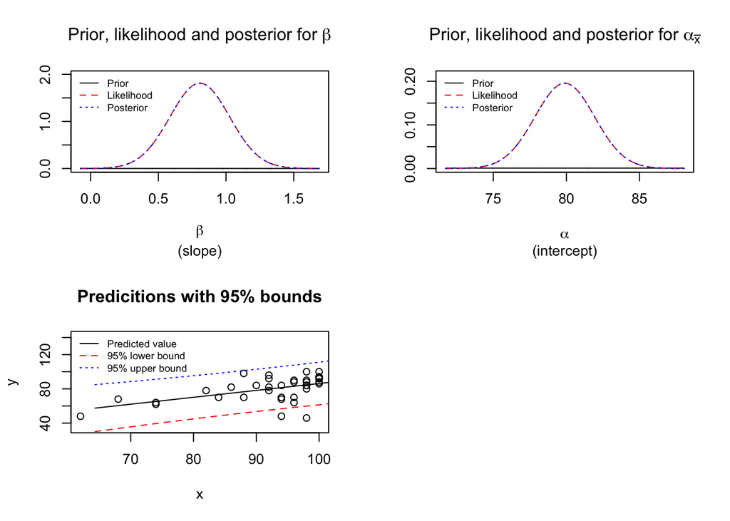

```r
library(Bolstad)

bayes.lin.reg(y = reg_data$MidtermThree, x = reg_data$MidtermOne, slope.prior = "flat", intcpt.prior = "flat", plot.data = TRUE)
```

```
## Standard deviation of residuals:  12.4
```

```
##             Posterior Mean Posterior Std. Deviation
##             -------------- ------------------------
## Intercept:  79.95          1.4283
## Slope:      0.1378         0.091054
```

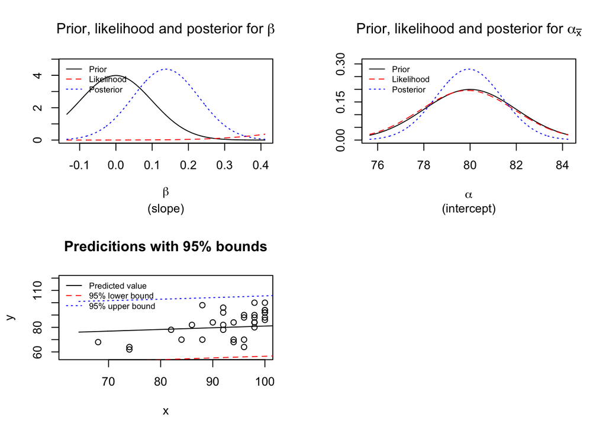

```r
bayes.lin.reg(y = reg_data$MidtermThree, x = reg_data$MidtermOne, slope.prior = "normal", intcpt.prior = "normal", mb0=0, sb0 = 0.1, ma0 = 80, sa0 = 2, plot.data = TRUE)
```

## III. Credible intervals and hypothesis testing (14.5; 10 - 15 min)

### Bayesian credible interval around the slope

Just normal model here. Please find a 95% credible interval under your priors with unknown variance.

### Frequentist credible interval around the slopee

$\hat{\beta} \pm t_{\alpha/2,df=n-2} \frac{\hat{\sigma}}{\sqrt{SS_x}}$.

### Testing One-sided hypothesis about slope

Please test whether the slope is larger than 0.

### Testing Two-sided hypothesis about slope

Please test whether the slope is different from 0.

## IV. Predictive ditribution for the regression model (14.5; 10 - 15 min)

### Finding the predictive distribution

Discuss the derivation.

### predictive distribution parameters

Please find the predictive distribution under your prior and unknown variance.

1. Find the predictive density when a student scores a 70 on the first exam.
2. Find a 95% prediction interval

## Closing (5 min)

- Write down your own answer to the guiding question, “How well does Midterm One scores predict Midterm Three?”
- Share.